# Getting Started with wnpmle

## Overview

The `wnpmle` package provides regression modeling for the marginal mean intensity of recurrent events in the presence of a competing terminal event for two large classes of semiparametric transformation models. The marginal mean intensity has a one-to-one correspondence with the marginal mean. Covariate effects are therefore directly interpretable with regard to the expected number of recurrences. Estimation is based on the weighted nonparametric maximum likelihood estimator (wNPMLE) by Bellach and Kosorok (2026), which extends the weighted NPMLE for competing risks (Bellach et al., 2019), and model selection is facilitated by the profile log-likelihood and the AIC.

Subjects who experience the terminal event remain in a pseudo-risk set, akin to a cure fraction, and their unobserved censoring times are accounted for by inverse probability of censoring weighting (IPCW). This approach facilitates consistent and direct prediction of the marginal mean. In contrast, other approaches remove terminal events from the risk set akin to censorings. This methodology leads to modeling the marginal mean conditional on survival, which is a biased estimate for the marginal mean.

| Models | Link function G(x) | Special cases |
| --- | --- | --- |
| Box-Cox transformation models (`model = "boxcox"`) | $((1 + x)^\rho - 1)/\rho$ | Ghosh–Lin ($\rho = 1$); $\log(1+x)$ as $\rho \to 0$ |
| Logarithmic transformation models (`model = "log"`) | $\log(1 + r x)/r$ | Proportional odds ($r = 1$); Ghosh–Lin as $r \to 0$ |

Both are estimated via automatic differentiation using TMB, which provides exact gradients and fast convergence.

## Installation

```r
install.packages("wnpmle")
```

Or from GitHub:

```r
# install.packages("remotes")
remotes::install_github("abellach/wnpmle")
```

## Quick start: bladder cancer data

The bladder cancer data from the Veterans Administration Cooperative Urological Research Group were previously analyzed by Ghosh and Lin (2002) and by Zeng and Lin (2006). `bladder_prep()` prepares the 86 patients treated with thiotepa or placebo from `survival::bladder1`, with treatment, the number of tumors and the size of the largest tumor at baseline as covariates. The Box-Cox model with $\rho = 1$, i.e. the identity link $G(x) = x$, is the Ghosh–Lin model, which is a special case of the weighted NPMLE (Bellach and Kosorok, 2026).

```r
library(wnpmle)

bdata <- bladder_prep()
fit_bladder <- wnpmle_fit(
  Surv(time, status) ~ treat + num + size,
  data  = bdata,
  id    = "id",
  model = "boxcox",
  rho   = 1,
  tau   = 59
)
```

[output not shown]

```r
fit_bladder
```

```
#>
#> Weighted NPMLE - Recurrent Events with Competing Terminal Event
#> Type       : recurrent
#> Model      : BOXCOX transformation ( rho = 1 )
#> Subjects   : 86
#> Events     : recurrent = 132   terminal = 22   censored = 64
#> Log-lik    : -683.5759
#> Convergence: relative convergence (4)
#>
#> Coefficients:
#>       Estimate     SE z value Pr(>|z|)
#> treat  -0.5363 0.2684  -1.998  0.04570
#> num     0.1727 0.0587   2.940  0.00328
#> size   -0.0051 0.0680  -0.074  0.94080
```

## Example: hospital readmissions after colorectal cancer surgery

The readmission data (Gonzalez et al., 2005) contain repeated hospital readmissions of 403 patients after surgery for colorectal cancer, with death as competing terminal event. `readmission_prep()` returns one row per readmission (status 1) and one final row per patient, either death (status 2) or censoring (status 0). Time is measured in days since surgery.

```r
rdata <- readmission_prep(tau = 1460)
head(rdata)
```

```
#>   id time status      chemo    sex dukes charlson
#> 1  1   24      1    Treated Female     D        3
#> 2  1  457      1    Treated Female     D        0
#> 3  1 1037      0    Treated Female     D        0
#> 4  2  489      1 NonTreated   Male     C        0
#> 5  2 1182      0 NonTreated   Male     C        0
#> 6  3   15      1 NonTreated   Male     C        3
```

```r
table(rdata$status)
```

```
#>
#>   0   1   2
#> 296 447 107
```

The covariates are chemotherapy, sex, Dukes’ tumor stage and the Charlson comorbidity index. For our analysis we set $\tau = 4$ years (1460 days): readmissions after $\tau$ are removed and patients still under observation are censored at $\tau$. At $\tau$, 25% of the patients are still followed and 98% of the readmissions have occurred, while beyond $\tau$ the number of patients at risk drops rapidly (21 patients at 5 years).

### Choosing the transformation

`plot_loglik()` plots the profile log-likelihood over a grid of transformation parameters for both model classes, with $r$ (logarithmic) on the left and $\rho$ (Box-Cox) on the right. The open circle marks the Ghosh–Lin model ($\rho = 1$), the filled circle the proportional odds model ($r = 1$).

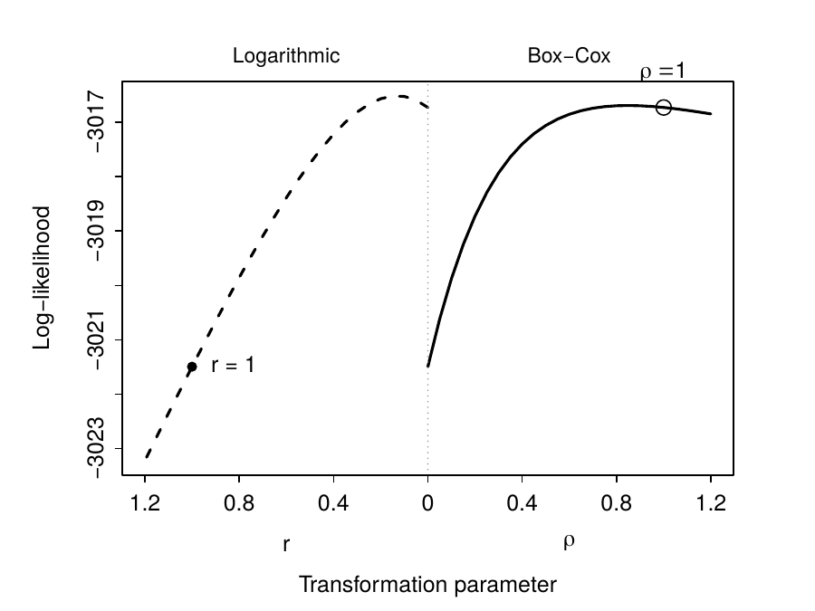

```r
plot_loglik(
  Surv(time, status) ~ chemo + sex + dukes + charlson,
  data     = rdata,
  id       = "id",
  tau      = 1460,
  rho_grid = seq(0.05, 1.2, by = 0.05),
  r_grid   = seq(0.05, 1.2, by = 0.05)
)
```

The maxima are at $\hat\rho \approx 0.85$ and $\hat r \approx 0.15$, both close to the Ghosh–Lin model. The exact optima can be found with `optimize()`:

```r
f <- function(p) wnpmle_fit(Surv(time, status) ~ chemo + sex + dukes + charlson,
                            data = rdata, id = "id", model = "boxcox", rho = p,
                            tau = 1460, se = "none")$loglik
optimize(f, interval = c(0.2, 1), maximum = TRUE)
```

[output not shown]

### Fitting the selected model

```r
fit_rd <- wnpmle_fit(
  Surv(time, status) ~ chemo + sex + dukes + charlson,
  data  = rdata,
  id    = "id",
  model = "boxcox",
  rho   = 0.85,
  tau   = 1460,
  se    = "sandwich_adj"
)
summary(fit_rd)
```

```
#>
#> Weighted NPMLE - Recurrent Events with Competing Terminal Event
#> Type       : recurrent
#> Model      : BOXCOX transformation ( rho = 0.85 )
#> Subjects   : 403
#> Events     : recurrent = 447   terminal = 107   censored = 296
#> Log-lik    : -3016.694
#> Convergence: relative convergence (4)
#>
#> Coefficients:
#>              Estimate     SE z value  Pr(>|z|)
#> chemoTreated  -0.6079 0.1861  -3.267 0.0010880
#> sexFemale     -0.5159 0.1792  -2.879 0.0039920
#> dukesC         0.2823 0.1991   1.418 0.1562000
#> dukesD         0.9322 0.2765   3.371 0.0007483
#> charlson1-2    0.7336 0.4075   1.800 0.0718000
#> charlson3     -0.0805 0.1957  -0.411 0.6808000
#>
#> Cumulative baseline mean at time grid:
#>                 Lambda     SE
#> A(tau/4) = 365  0.7016 0.1371
#> A(tau/2) = 730  1.0874 0.1994
#> A(tau)   = 1460 1.5716 0.2711
```

Comparison with the Ghosh–Lin and proportional odds models:

```r
fit_gl <- wnpmle_fit(Surv(time, status) ~ chemo + sex + dukes + charlson,
                     data = rdata, id = "id", model = "boxcox", rho = 1,
                     tau = 1460, se = "none")
fit_po <- wnpmle_fit(Surv(time, status) ~ chemo + sex + dukes + charlson,
                     data = rdata, id = "id", model = "log", rho = 1,
                     tau = 1460, se = "none")
```

```
#> Note: Using Makevars in C:\Users\abell\AppData\Local\Temp\RtmpMZz5ds\file93cc2ded7de9
#> using C++ compiler: 'G__~1.EXE (GCC) 13.3.0'
```

```r
sapply(list(boxcox_0.85 = fit_rd, ghosh_lin = fit_gl, prop_odds = fit_po), AIC)
```

```
#> boxcox_0.85   ghosh_lin   prop_odds
#>    6045.388    6045.461    6054.987
```

In the selected model, chemotherapy, sex and Dukes’ stage D have a significant effect on the expected number of readmissions.

A positive coefficient increases and a negative coefficient decreases the expected number of recurrences at all times. In the Ghosh–Lin model ($\rho = 1$), $\exp(\beta)$ is the ratio of the marginal means; in the proportional odds model ($r = 1$), $\exp(\beta)$ is the ratio of $\exp(\mu(t)) - 1$, where $\mu(t)$ is the marginal mean. For other transformation models, the size of the effect depends on time and is best illustrated with `predict()`, as shown below.

### Cumulative baseline mean

`baseline()` returns the cumulative baseline mean with pointwise 95% confidence limits.

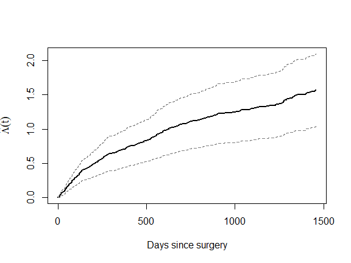

```r
bl <- baseline(fit_rd)
plot(bl$time, bl$Lambda, type = "s", lwd = 2,
     xlab = "Days since surgery", ylab = expression(hat(Lambda)(t)),
     ylim = range(c(bl$lower, bl$upper), na.rm = TRUE))
lines(bl$time, bl$lower, type = "s", lty = 2, col = "grey50")
lines(bl$time, bl$upper, type = "s", lty = 2, col = "grey50")
```

### Prediction

`predict()` gives the marginal mean with pointwise 95% confidence limits at new covariate values, here for a man with Dukes’ stage C and Charlson index 0, with and without chemotherapy.

```r
newdat <- data.frame(chemo    = c("NonTreated", "Treated"),
                     sex      = "Male",
                     dukes    = "C",
                     charlson = "0")
pred <- predict(fit_rd, newdata = newdat, times = seq(0, 1460, by = 7))
head(pred)
```

```
#>   time       mu_1     lower_1    upper_1       mu_2     lower_2    upper_2
#> 1    0 0.00000000 0.000000000 0.00000000 0.00000000 0.000000000 0.00000000
#> 2    7 0.02214344 0.009756028 0.05025939 0.01206602 0.004954678 0.02938414
#> 3   14 0.05192327 0.028269828 0.09536760 0.02832098 0.014213503 0.05643071
#> 4   21 0.08541735 0.051230223 0.14241836 0.04664011 0.025176942 0.08640049
#> 5   28 0.10400615 0.064370436 0.16804732 0.05682323 0.031239694 0.10335824
#> 6   35 0.11891761 0.075519166 0.18725575 0.06500002 0.036408368 0.11604481
```

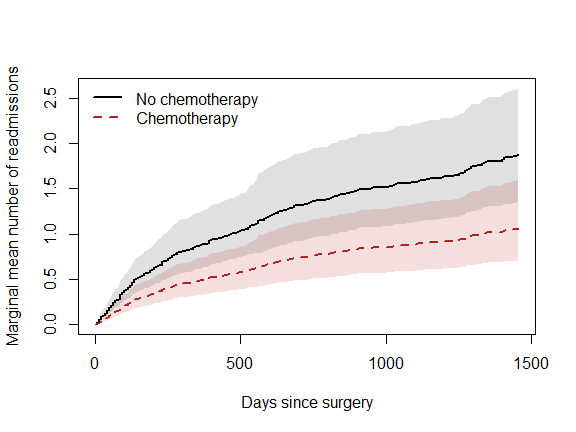

```r
plot(pred$time, pred$mu_1, type = "n",
     xlab = "Days since surgery",
     ylab = "Marginal mean number of readmissions",
     ylim = range(pred[, -1]))
polygon(c(pred$time, rev(pred$time)), c(pred$lower_1, rev(pred$upper_1)),
        col = adjustcolor("black", 0.12), border = NA)
polygon(c(pred$time, rev(pred$time)), c(pred$lower_2, rev(pred$upper_2)),
        col = adjustcolor("firebrick", 0.15), border = NA)
lines(pred$time, pred$mu_1, type = "s", lwd = 2)
lines(pred$time, pred$mu_2, type = "s", lwd = 2, lty = 2, col = "firebrick")
legend("topleft", legend = c("No chemotherapy", "Chemotherapy"),
       lty = c(1, 2), col = c("black", "firebrick"), lwd = 2, bty = "n")
```

## Standard errors

| Value | Description |
| --- | --- |
| `"sandwich_adj"` | Sandwich variance estimator with correction for the estimated censoring weights (default) |
| `"sandwich"` | Sandwich variance estimator without the correction |
| `"fisher"` | Inverse Fisher information |
| `"none"` | No standard errors; faster, useful for profiling |

All standard errors are computed with TMB and are fast also for large data sets.

## S3 methods and helpers

| Function | Description |
| --- | --- |
| `print(fit)` | Compact coefficient table with z-values and p-values |
| `summary(fit)` | Adds the cumulative baseline at tau/4, tau/2, tau |
| `coef(fit)` | Named coefficient vector |
| `vcov(fit)` | Full variance-covariance matrix for (beta, Lambda) |
| `logLik(fit)`, `AIC(fit)`, `BIC(fit)` | Log-likelihood and information criteria |
| `baseline(fit)` | Cumulative baseline mean with pointwise confidence limits |
| `predict(fit, newdata)` | Marginal mean at new covariate values |
| `plot_loglik()` | Profile log-likelihood over the transformation parameter |
| `bladder_prep()`, `readmission_prep()` | Example data sets |

## References

Bellach, A. and Kosorok, M.R. (2026). Weighted NPMLE for the marginal mean of recurrent events with a competing terminal event. *arXiv preprint* arXiv:2605.25934. [doi:10.48550/arXiv.2605.25934](https://doi.org/10.48550/arXiv.2605.25934).

Bellach, A., Kosorok, M.R., Rüschendorf, L. and Fine, J.P. (2019). Weighted NPMLE for the subdistribution of a competing risk. *Journal of the American Statistical Association*, 114(525), 259–270. [doi:10.1080/01621459.2017.1401540](https://doi.org/10.1080/01621459.2017.1401540).

Ghosh, D. and Lin, D.Y. (2002). Marginal regression models for recurrent and terminal events. *Statistica Sinica*, 12, 663–688. [doi:10.17615/pt0g-y207](https://doi.org/10.17615/pt0g-y207).

Gonzalez, J.R., Fernandez, E., Moreno, V., Ribes, J., Peris, M., Navarro, M., Cambray, M. and Borras, J.M. (2005). Sex differences in hospital readmission among colorectal cancer patients. *Journal of Epidemiology and Community Health*, 59(6), 506–511. [doi:10.1136/jech.2004.028902](https://doi.org/10.1136/jech.2004.028902).

Zeng, D. and Lin, D.Y. (2006). Semiparametric transformation models with random effects for recurrent events. *Biometrika*, 93(3), 627–640. [doi:10.1093/biomet/93.3.627](https://doi.org/10.1093/biomet/93.3.627).